[O’Hara on GitHub](https://github.com/oharac)

# Figure 5: Comparing species and FE impacts

Compiled on Thu Oct 9 22:56:39 2025 by ohara

```r
knitr::opts_chunk$set(echo = TRUE, message = FALSE, warning = FALSE, fig.height = 4, fig.width = 7)

library(terra)
library(sf)
library(oharac)
library(data.table)
library(tidyverse)
library(biscale)  ### for bivariate legend
library(cowplot)
library(here)
source(here('common_fxns.R'))
```

# 1 Summary

Create Fig. 5 for manuscript

# 2 Data

Results from scripts in folder `2_process_spp_vuln_and_impacts`

# 3 Methods

Read in the output rasters for species-level impacts (unweighted); reclassify based on quartile/quintile. Fig. 5A is bivariate plot of climate stressors for species and FE quartiles, Fig. 5B is bivariate plot of non-climate stressors for species and FE quartiles; Fig. 1C and 1D are %difference plots for each category.

```r
ocean_map <- rast(here('_spatial/ocean_area_mol.tif'))
ocean_df <- as.data.frame(ocean_map, xy = TRUE)

land_sf <- read_sf(here('_spatial/ne_10m_land/ne_10m_land_no_casp.shp')) %>%
  st_transform(st_crs(ocean_map))

chi_gps_fe <- list.files(here('_output/cumulative_impact_maps'),
                          pattern = 'funct_entity_group_chi',
                          full.names = TRUE)
chi_gps_spp <- list.files(here('_output/cumulative_impact_maps'),
                          pattern = 'species_group_chi',
                          full.names = TRUE)
climate_map_fe <- rast(chi_gps_fe[1])
climate_map_spp <- rast(chi_gps_spp[1])

nonclimate_map_fe <- rast(chi_gps_fe[2:4]) %>%
  sum(na.rm = TRUE)

nonclimate_map_spp  <- rast(chi_gps_spp[2:4]) %>%
  sum(na.rm = TRUE)
```

### 3.0.1 Reclassify

Reclassify values using `ntile` to get quartile values:

```r
cc_qtile_fe <- noncc_qtile_fe <- climate_map_fe ### initialize two new maps
values(cc_qtile_fe) <- ntile(values(climate_map_fe), 4)
values(noncc_qtile_fe) <- ntile(values(nonclimate_map_fe), 4)

cc_fe_df <- as.data.frame(cc_qtile_fe, xy = TRUE) %>%
  setNames(c('x', 'y', 'cc_fe'))
noncc_fe_df <- as.data.frame(noncc_qtile_fe, xy = TRUE) %>%
  setNames(c('x', 'y', 'noncc_fe'))

cc_noncc_fe_df <- dt_join(cc_fe_df, noncc_fe_df, by = c('x', 'y'), type = 'full') %>%
  mutate(bi_class = paste(cc_fe, noncc_fe, sep = '-'))
```

```r
cc_qtile_spp <- noncc_qtile_spp <- climate_map_spp ### initialize two new maps
values(cc_qtile_spp) <- ntile(values(climate_map_spp), 4)
values(noncc_qtile_spp) <- ntile(values(nonclimate_map_spp), 4)
```

## 3.1 Create panels

### 3.1.1 Species impact hot/cool spots overlap with FE impact

Compare the species CHI hot/cool spots with FE - incl Sørensen similarity

```r
cc_spp_df <- as.data.frame(cc_qtile_spp, xy = TRUE) %>%
  setNames(c('x', 'y', 'cc_spp'))
noncc_spp_df <- as.data.frame(noncc_qtile_spp, xy = TRUE) %>%
  setNames(c('x', 'y', 'noncc_spp'))

cc_noncc_spp_df <- dt_join(cc_spp_df, noncc_spp_df,
                          by = c('x', 'y'), type = 'full') %>%
  mutate(bi_class = paste(cc_spp, noncc_spp, sep = '-'))

cc_match <- cc_spp_df %>%
  inner_join(cc_fe_df, by = c('x', 'y')) %>%
  mutate(match = case_when(cc_fe == cc_spp ~ 'a',
                           TRUE ~ 'b')) %>%
  group_by(match) %>%
  summarize(n_gp = n()) %>%
  spread(match, n_gp) %>%
  mutate(jaccard = a / (a + b),
         sorensen = 2*a / (2*a + b))
knitr::kable(cc_match)
```

| a | b | jaccard | sorensen |
| --- | --- | --- | --- |
| 2214519 | 1465473 | 0.6017728 | 0.7513834 |

```r
noncc_match <- noncc_spp_df %>%
  inner_join(noncc_fe_df, by = c('x', 'y')) %>%
  mutate(r = runif(n = n())) %>%
  mutate(match = case_when(noncc_fe == noncc_spp ~ 'a',
                           TRUE ~ 'b')) %>%
  group_by(match) %>%
  summarize(n_gp = n()) %>%
  spread(match, n_gp) %>%
  mutate(jaccard = a / (a + b),
         sorensen = 2*a / (2*a + b))
knitr::kable(noncc_match)
```

| a | b | jaccard | sorensen |
| --- | --- | --- | --- |
| 3182304 | 497688 | 0.8647584 | 0.927475 |

### 3.1.2 Panel A and B: spp-FE climate and non-climate overlap

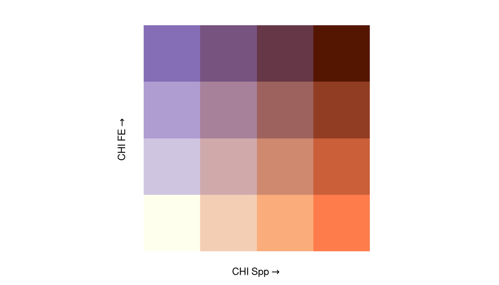

```r
map_pal_raw <- bi_pal(pal = 'PurpleOr', dim = 4, preview = FALSE)

map_pal_mtx      <- matrix(map_pal_raw, nrow = 4, ncol = 4)
map_pal_mtx[3, ] <- colorspace::lighten(map_pal_mtx[3, ], .1)
map_pal_mtx[2, ] <- colorspace::lighten(map_pal_mtx[2, ], .2)
map_pal_mtx[1, ] <- colorspace::lighten(map_pal_mtx[1, ], .3)
map_pal_mtx[ , 3] <- colorspace::lighten(map_pal_mtx[ , 3], .1)
map_pal_mtx[ , 2] <- colorspace::lighten(map_pal_mtx[ , 2], .2)
map_pal_mtx[ , 1] <- colorspace::lighten(map_pal_mtx[ , 1], .3)
map_pal_mtx[1, 1] <- '#ffffee'

map_pal <- as.vector(map_pal_mtx) %>% setNames(names(map_pal_raw))

panel_lgd_raw <- bi_legend(pal = map_pal, dim = 4,
                           x = 'CHI Spp',
                           y = 'CHI FE')
panel_lgd_raw
```

```r
globe_bbox <- rbind(c(-180, -90), c(-180, 90),
                      c(180, 90), c(180, -90), c(-180, -90))
globe_border <- st_polygon(list(globe_bbox)) %>%
  st_sfc(crs = 4326) %>%
  st_sf(data.frame(rgn = 'globe', geom = .)) %>%
  smoothr::densify(max_distance = 0.5) %>%
  st_transform(crs = crs(ocean_map))
```

```r
cc_spp_fe_df <- dt_join(cc_fe_df, cc_spp_df, by = c('x', 'y'), type = 'full') %>%
  mutate(bi_class = paste(cc_fe, cc_spp, sep = '-')) %>%
  filter(!is.na(cc_spp) & !is.na(cc_fe))

fe_overlap_summary <- cc_spp_fe_df %>%
  group_by(bi_class) %>%
  summarize(ncell = n(),
            pct = n() / nrow(.))
knitr::kable(fe_overlap_summary, digits = 4,
             col.names = c('spp/FE CHI overlap, climate', '# of cells', '% of area'))
```

| spp/FE CHI overlap, climate | # of cells | % of area |
| --- | --- | --- |
| 1-1 | 658775 | 0.1790 |
| 1-2 | 238828 | 0.0649 |
| 1-3 | 22371 | 0.0061 |
| 1-4 | 24 | 0.0000 |
| 2-1 | 231793 | 0.0630 |
| 2-2 | 402692 | 0.1094 |
| 2-3 | 260104 | 0.0707 |
| 2-4 | 25409 | 0.0069 |
| 3-1 | 29099 | 0.0079 |
| 3-2 | 254232 | 0.0691 |
| 3-3 | 447577 | 0.1216 |
| 3-4 | 189090 | 0.0514 |
| 4-1 | 331 | 0.0001 |
| 4-2 | 24246 | 0.0066 |
| 4-3 | 189946 | 0.0516 |
| 4-4 | 705475 | 0.1917 |

```r
panel_a <- ggplot() +
  ### background for NA cells:
  geom_raster(data = ocean_df, aes(x, y), fill = 'grey85') +
  ### plot data:
  geom_raster(data = cc_spp_fe_df, aes(x, y, fill = bi_class), show.legend = FALSE) +
  bi_scale_fill(pal = map_pal, dim = 4) +
  ### continents:
  geom_sf(data = land_sf,
          fill = 'grey96', color = NA,
          size = .1) +
  geom_sf(data = globe_border,
          fill = NA, color = 'grey70',
          size = .1) +
  scale_x_continuous(expand = c(0, 0)) +
  scale_y_continuous(expand = c(0, 0)) +
  theme_void() +
  theme(axis.text = element_blank(),
        axis.title = element_blank())
```

```r
noncc_spp_fe_df <- dt_join(noncc_fe_df, noncc_spp_df, by = c('x', 'y'), type = 'full') %>%
  mutate(bi_class = paste(noncc_fe, noncc_spp, sep = '-')) %>%
  filter(!is.na(noncc_spp) & !is.na(noncc_fe))

fe_overlap_summary <- noncc_spp_fe_df %>%
  group_by(bi_class) %>%
  summarize(ncell = n(),
            pct = n() / nrow(.))
knitr::kable(fe_overlap_summary, digits = 4,
             col.names = c('spp/FE CHI overlap, nonclimate', '# of cells', '% of area'))
```

| spp/FE CHI overlap, nonclimate | # of cells | % of area |
| --- | --- | --- |
| 1-1 | 859594 | 0.2336 |
| 1-2 | 50821 | 0.0138 |
| 1-3 | 9119 | 0.0025 |
| 1-4 | 464 | 0.0001 |
| 2-1 | 59802 | 0.0163 |
| 2-2 | 745202 | 0.2025 |
| 2-3 | 107236 | 0.0291 |
| 2-4 | 7758 | 0.0021 |
| 3-1 | 602 | 0.0002 |
| 3-2 | 122434 | 0.0333 |
| 3-3 | 731347 | 0.1987 |
| 3-4 | 65615 | 0.0178 |
| 4-2 | 1541 | 0.0004 |
| 4-3 | 72296 | 0.0196 |
| 4-4 | 846161 | 0.2299 |

```r
panel_b <- ggplot() +
  ### background for NA cells:
  geom_raster(data = ocean_df, aes(x, y), fill = 'grey85') +
  ### plot data:
  geom_raster(data = noncc_spp_fe_df, aes(x, y, fill = bi_class), show.legend = FALSE) +
  bi_scale_fill(pal = map_pal, dim = 4) +
  ### continents:
  geom_sf(data = land_sf,
          fill = 'grey96', color = NA,
          size = .1) +
  geom_sf(data = globe_border,
          fill = NA, color = 'grey70',
          size = .1) +
  scale_x_continuous(expand = c(0, 0)) +
  scale_y_continuous(expand = c(0, 0)) +
  theme_void() +
  theme(axis.text = element_blank(),
        axis.title = element_blank())
```

### 3.1.3 Panel C and D: difference, spp-average vs fe-average

Here we calculate the “residuals” as just the difference, assuming a 1:1 model, since as FEs become more and more specific (membership –> 1) the FE weighting approaches the spp equal-weighting.

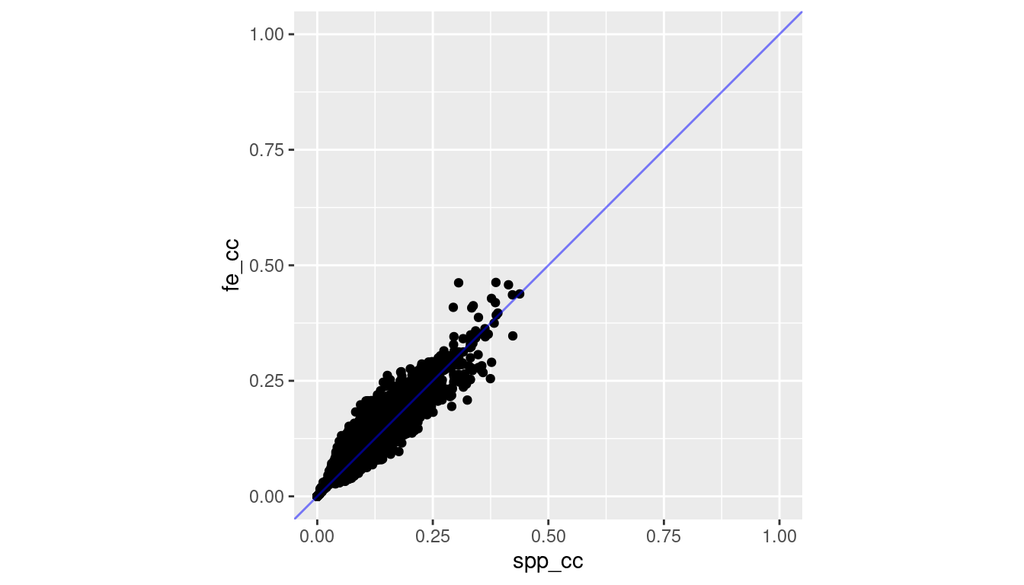

```r
fe_vs_spp_stack <- rast(list(spp_cc = climate_map_spp,
                             spp_noncc = nonclimate_map_spp,
                             fe_cc = climate_map_fe,
                             fe_noncc = nonclimate_map_fe))

### Keep raster values with xy = TRUE, no need for cell IDs
spp_vs_fe_df <- as.data.frame(fe_vs_spp_stack, xy = TRUE)

### generate a LM based on climate stressors
cc_mdl <- lm(fe_cc ~ spp_cc + 0, data = spp_vs_fe_df)
ggplot(spp_vs_fe_df %>% sample_n(10000), aes(x = spp_cc, y = fe_cc)) +
  geom_point() +
  geom_abline(intercept = cc_mdl$coefficients[1],
              slope = cc_mdl$coefficients[2],
              color = 'red') +
  geom_abline(intercept = 0,
              slope = 1,
              color = 'blue', alpha = .5) +
  coord_fixed() +
  xlim(c(0, 1)) + ylim(c(0, 1))
```

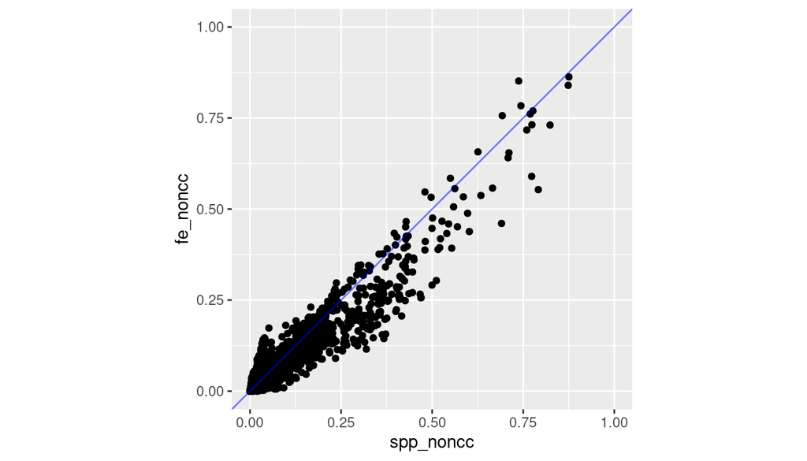

```r
### generate a LM based on non-climate stressors
noncc_mdl <- lm(fe_noncc ~ spp_noncc + 0, data = spp_vs_fe_df)
ggplot(spp_vs_fe_df %>% sample_n(10000), aes(x = spp_noncc, y = fe_noncc)) +
  geom_point() +
  geom_abline(intercept = noncc_mdl$coefficients[1],
              slope = noncc_mdl$coefficients[2],
              color = 'red') +
  geom_abline(intercept = 0,
              slope = 1,
              color = 'blue', alpha = .5) +
  coord_fixed() +
  xlim(c(0, 1)) + ylim(c(0, 1))
```

$$I_{FE}^{cc} = 1.065 I_{spp}^{cc} + 0
\quad (adj.R^2 = 0.959)$$

$$I_{FE}^{non-cc} = .830 I_{spp}^{non-cc}
+ 0 \quad (adj.R^2 = 0.923)$$

These high R<sup>2</sup> values are expected - the underlying data is identical (presence/absence of each species, vulnerability of each species, intensity of impact) - the difference is in weighting the impact of each species by its importance to distinct functional entities. Where the two metrics diverge, this is due to differences in impacts on community structure.

```r
spp_vs_fe_diff_df <- spp_vs_fe_df %>%
  mutate(cc_diff = fe_cc - spp_cc,
         noncc_diff = fe_noncc - spp_noncc) %>%
  mutate(cc_diff2 = case_when(cc_diff > .2  ~ .2,
                              cc_diff < -.2 ~ -.2,
                              TRUE ~ cc_diff),
         noncc_diff2 = case_when(noncc_diff > .2  ~ .2,
                                 noncc_diff < -.2 ~ -.2,
                                 TRUE ~ noncc_diff))
```

```r
# clrs <- c('#005600', '#42a644', '#fffff8', '#dd6ba6', '#841859')
clrs <- c('#005600', '#42a644', '#f8f8ff', '#dd6ba6', '#841859')
brks <- c(-.2, -.1, 0, .1, .2)
lims <- c(-.2, .2)
lbls <- c('≤-.20', '-.10', '0', '.10', '≥.20')

panel_c_cc <- ggplot() +
  ### background for NA cells:
  geom_raster(data = ocean_df, aes(x, y), fill = 'grey85') +
  ### plot data:
  geom_raster(data = spp_vs_fe_diff_df,
              aes(x, y, fill = cc_diff2)) +
  scale_fill_gradientn(colors = clrs,
                       breaks = brks,
                       labels = lbls,
                       limits = lims,
                       na.value = 'grey96') +
  ### continents:
  geom_sf(data = land_sf,
          fill = 'grey96', color = 'grey40',
          size = .10) +
  geom_sf(data = globe_border,
          fill = NA, color = 'grey70',
          size = .1) +
  scale_x_continuous(expand = c(0, 0)) +
  scale_y_continuous(expand = c(0, 0)) +
  theme_void() +
  theme(text = element_text(family = 'Arial'),
        axis.text = element_blank(),
        axis.title = element_blank(),
        legend.key.height = unit(.16, 'in'),
        legend.key.width = unit(.32, 'in'),
        legend.spacing = unit(0, 'cm'),
        legend.margin = margin(0, 0, 0, 0, unit = 'pt'),
        legend.text = element_text(size = 8, color = 'black',
                                   hjust = 0.5, vjust = 0, angle = 0),
        legend.direction = 'horizontal',
        legend.title = element_blank())

# panel_c_cc
```

```r
panel_d_noncc <- ggplot() +
  ### background for NA cells:
  geom_raster(data = ocean_df, aes(x, y), fill = 'grey85') +
  ### plot data:
  geom_raster(data = spp_vs_fe_diff_df,
              aes(x, y, fill = noncc_diff2)) +
  scale_fill_gradientn(colors = clrs,
                       breaks = brks,
                       labels = lbls,
                       limits = lims,
                       na.value = 'grey96') +
  ### continents:
  geom_sf(data = land_sf,
          fill = 'grey96', color = 'grey40',
          size = .10) +
  geom_sf(data = globe_border,
          fill = NA, color = 'grey70',
          size = .1) +
  scale_x_continuous(expand = c(0, 0)) +
  scale_y_continuous(expand = c(0, 0)) +
  theme_void() +
  theme(axis.text = element_blank(),
        axis.title = element_blank(),
        legend.position = 'none')

# panel_d_noncc
```

## 3.2 Assemble figure

```r
fig5_file <- here('5_ms_figs/fig5_comparing_fe_vs_spp_chi.png')
panel_a_map  <- get_panel(panel_a)
panel_b_map  <- get_panel(panel_b)
panel_c_map  <- get_panel(panel_c_cc)
panel_d_map  <- get_panel(panel_d_noncc)
panel_ab_lgd <- get_panel(panel_lgd_raw)
panel_cd_lgd <- get_legend(panel_c_cc)
```

```r
### parameterize panels for easier changing
p_w <- 0.55
p_h <- p_w / 2 * 6/5
a <- c(x = 0.00, y = 0.645)
b <- c(x = 1-p_w, y = 0.43)
c <- c(x = 0.00, y = 0.215)
d <- c(x = 1-p_w, y = 0.0)

fig5_panels <- ggdraw() +
  draw_plot(panel_a_map,  x = a['x'], y = a['y'], height = p_h, width = p_w) +
  draw_plot(panel_b_map,  x = b['x'], y = b['y'], height = p_h, width = p_w) +
  draw_plot(panel_c_map,  x = c['x'], y = c['y'], height = p_h, width = p_w) +
  draw_plot(panel_d_map,  x = d['x'], y = d['y'], height = p_h, width = p_w)

fig5_labels <- fig5_panels +
  draw_label('A. Climate', x = a['x'], y = a['y'] + p_h,  hjust = 0, vjust = 0,
             size = 12, fontfamily = 'Arial', fontface = 'bold') +
  draw_label('B. Non-climate', x = 1,      y = b['y'] + p_h,  hjust = 1, vjust = 0,
             size = 12, fontfamily = 'Arial', fontface = 'bold') +
  draw_label('C. Climate', x = c['x'], y = c['y'] + p_h,  hjust = 0, vjust = 0,
             size = 12, fontfamily = 'Arial', fontface = 'bold') +
  draw_label('D. Non-climate', x = 1,      y = d['y'] + p_h,  hjust = 1, vjust = 0,
             size = 12, fontfamily = 'Arial', fontface = 'bold')
```

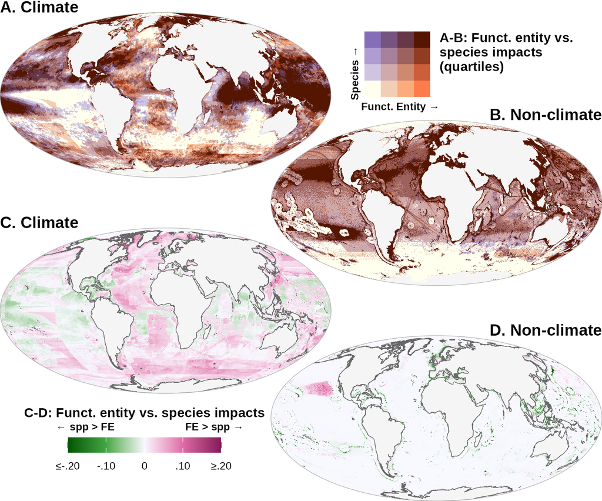

```r
### parameterize legends for easier changing of label positions:
l1 <- c(x = .60, y = 0.80, h = .144, w = .12)
l2 <- c(x = .02, y = 0.06, h = .07, w = .44)

fig5_legends <- fig5_labels +
  ### draw legends:
  draw_plot(panel_ab_lgd, x = l1['x'], y = l1['y'],
            height = l1['h'], width = l1['w']) +
  draw_plot(panel_cd_lgd, x = l2['x'], y = l2['y'],
            height = l2['h'], width = l2['w']) +
  ### Legend labels for biscale:
  draw_label('A-B: Funct. entity vs.\nspecies impacts\n(quartiles)',
             x = l1['x'] + l1['w'] + .01, y = l1['y'] + l1['h'] - .01,
             hjust = 0, vjust = 1, angle = 0,
             size = 10, color = 'black', fontfamily = 'Arial', fontface = 'bold') +
  draw_label('Funct. Entity →',
             x = l1['x'], y = l1['y'] - .005,
             hjust = 0, vjust = 1, angle = 0,
             size = 8, color = 'black', fontfamily = 'Arial', fontface = 'bold') +
  draw_label('Species →',
             x = l1['x'] - .005, y = l1['y'],
             hjust = 0, vjust = 0, angle = 90,
             size = 8, color = 'black', fontfamily = 'Arial', fontface = 'bold') +
  ### Legend label for diff plots
  draw_label('C-D: Funct. entity vs. species impacts',
             x = .24, y = .185, hjust = 0.5, vjust = 1, angle = 0,
             size = 10, color = 'black', fontfamily = 'Arial', fontface = 'bold') +
  draw_label('← spp > FE',
             x = .093, y = .156, hjust = 0, vjust = 1, angle = 0,
             size = 8, color = 'black', fontfamily = 'Arial', fontface = 'bold') +
  draw_label('FE > spp →',
             x = .405, y = .156, hjust = 1, vjust = 1, angle = 0,
             size = 8, color = 'black', fontfamily = 'Arial', fontface = 'bold')


ggsave(fig5_file, width = 6.25, height = 5.2, units = 'in', dpi = 300)
# ggsave(fig5_file %>% str_replace('.png$', '.tif'), width = 6.25, height = 5.2, units = 'in', dpi = 300)

knitr::include_graphics(fig5_file)
```